# Report of the second field trip to Baringo, Kenya

The Future Invasions Team

20-05-2019

# Introduction

This is a report of outcomes of two meetings held on 17<sup>th</sup> and 20<sup>th</sup> of May in Bonn.

Participants:

- Mathias Becker
- Thomas Heckelei
- Martin Tabe-Ojong
- Kathy Baylis
- Miguel Alvarez

## Next meeting

Wednesday 19<sup>th</sup> of June, 2019  
10:00 CET  
Location: To be confirmed

# Site selection and sampling

## Land cover classes

Selection of study sites for the surveys on *Parthenium hysterophorus* will be defined by a cross-classification of “dominant land use” (land cover) and landscape (soil) units:

|  | Plains | Alluvial Fans | Wetlands | River Banks | Bare Sodic Soils |
| --- | --- | --- | --- | --- | --- |
| Irrigated Cropland | 1a | 1b | – | – | – |
| Rainfed Cropland | – | 2 | – | – | – |
| Grassland | 3a | – | 3b | – | – |
| Fallow | – | – | 4 | 5 | 6 |

Classes are called after land cover classes defined by remote sensing in an on-going spatial classification. The further list contains a detailed description of those classes:

- **1.** Croplands in irrigation schemes, characterized by high intensity, production with commercial purposes (i.e. maize seed production, vegetables and fruit trees) and longer duration of vegetative periods. Most of those irrigation schemes are established on the plains with the exception of Sandai, which is lies over an alluvial plain. Thus this class is split into two subclasses of different soil conditions but similar vegetation dynamic.
  - **1a.** Irrigated croplands on the plains.
  - **1b.** Irrigated croplands on alluvial fans.
- **2.** Rainfed croplands, mainly established on alluvial fans and characterized by low vegetative duration, low intensity, production subsistence purposes and highly prone to soil erosion.
- **3.** Grasslands of communal use. Most of them are associated to seasonally flooded conditions that make the plots unsuitable neither for cultivation nor for the establishment of woody plants. While we recognized a central area on the Marigat plains with probably primary grasslands, There are some further grasslands areas separated in a second sub-class:
  - **3a.** Primary grasslands in seasonally flooded plains.
  - **3b.** Secondary grasslands along lake shores or wetlands, usually established after clear-cut of reeds and introduction of livestock. Some of those grasslands may be influenced by sodic soils, which is the case of *Cyperus laevigatus* grasslands at the Loboi swamps.
- **4.** Reeds. Natural stands dominated by *Typha domingensis*, *Cyperus papyrus*, tall grasses (*Echinochloa* sp.) and sedges.
- **5.** Riparian forests. Most of those stands also relatively natural and less suitable for cultivation. Nevertheless this class can be collated with cultivation, which may be going on bellow the canopy during dry seasons. Some of the trees may also be growing at the hedgerows of croplands.
- **6.** Bare sodic soils which are too dry for getting colonized by plants. Perhaps also soils under extreme moisture fluctuations. Some of the patches may be fringing wetlands and therefore covered by perennial vegetation, as in the case of the mentioned *Cyperus laevigatus* grasslands.

Three further classes are considered for sampling:

- **A.** Irrigation/drainage channels
- **B.** Roadsides
- **C.** Settlements

## Sampling strategy

For each class, 3 sampling points will be established by preferential sampling. In each of those points, three neighbouring plots of 2 m by 2 m (or 1 m by 4 m in lineal structures) will be marked. the location of the clusters will be recorded with a GPS-device and will be visited 4 times a year (quasi-permanent sampling).

In total, 33 sampling points (99 plots) will be selected for sample and data collection.

## Soil samples and analysis

Soil samples will be obtained from composites from every plot. They will be collected from two soil depths, namely 0-5 cm and 10-15 cm.

Among the variables that are selected for soil physical and chemical analyses there are two groups, the first of those are variables expected to be changing between different samplings and thus called **dynamic soil variables**:

- Soil moisture (TDR)
- pH
- Electric Conductivity

On the other side, there are **static soil variables** that may not change and thus sampled only once (perhaps a second time for quality check):

- Texture
- Bulk Density
- Hydraulic Conductivity
- Total Carbon
- Total Nitrogen
- Phosphorus
- Potassium
- Sodium

## Socio-economical assessment

Finally one of the important aspects for further planning is regarding the selection of households for the socio-economical surveys. For this decision additional information is required from prior site selection. Selected households may include people using the plots selected for the *Parthenium* survey.

# Cover Classification

Although this content was not included in the meeting, the on-going classification of land cover in the Marigat-Plains is very important for the selection of sampling localities and therefore preliminary results are shown in this report.

Six classes have been preliminarily defined (compare with sampling strategy). Those classes were obtained from a semi-supervises classification of land cover using classification tree (CART). A training set of pre-classified locations is used for the calibration of the tree as well as a set of potential factors including topographic position index (TPI) ant three statistics obtained from the calculation of the normalized difference vegetation index (NDVI). The dynamic of this index was measured from 17 LANDSAT scenes taken in 2018. From those scenes the maximum value, the oscillation (difference between maximum and minimum) and the texture of the mean value using grey-level co-occurrence matrix (variance and entropy) were included in the set of potential factors.

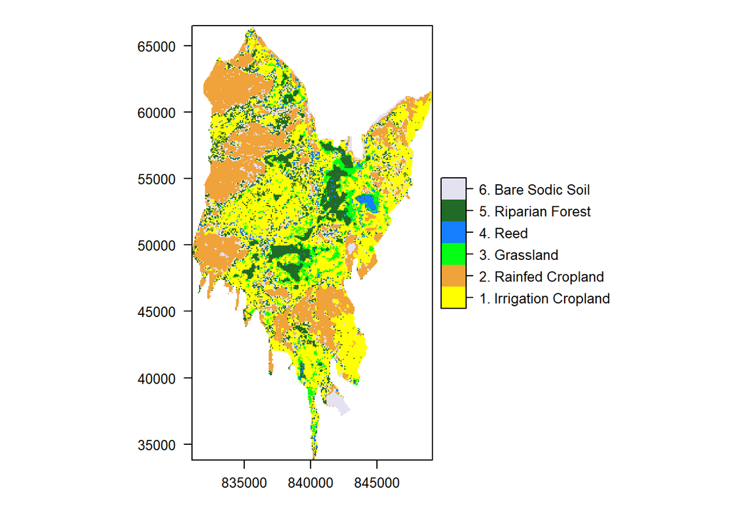

While the original idea was to improve the resolution of soil maps for the scale of this survey (most of the available maps are drown with a coarse scale), the obtained classes are reflecting the interaction between soil properties (geological substrate), land uses and hydrological dynamics.